# 2D PEMFC Cathode Two-Phase Transport

## Subject

- Expansion of the 1D reference work to 2D.
- Same assumptions as the reference
- Sweep $\eta$ over [0.05,0.075,0.1,0.15,0.2,0.25,0.3] V
- $\theta$ fixed at $91 ^ \circ$

## Mesh Generation with Gmsh GUI

- Higher mesh density at the GDL

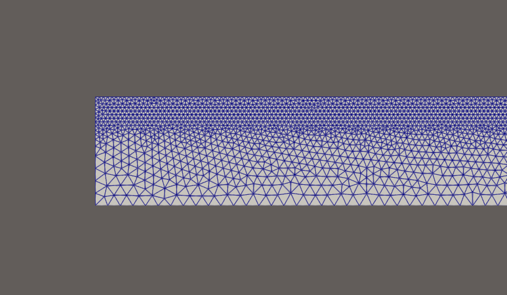

mesh

- GDL thickness $3 \times 10^{-4} m^2$
- Professor’s work $2.5 \times 10^{-4} m^2$
- Channel Length $0.05m$
- Professor’s work $0.002m$

## Verify velocity field

- Steady state; the momentum generation term is the Darcy term

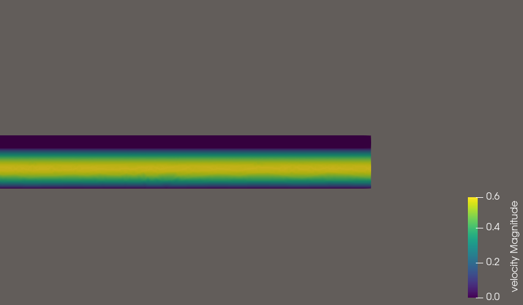

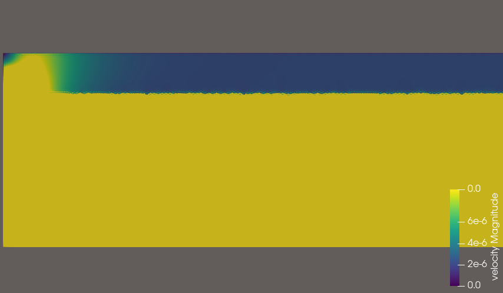

## Set Parameters

- Almost all parameters are the same as the reference
- Parameters not given
  - $\tau=1$
  - $\eta _{ohm}=\frac{IH_m}{\sigma _m}, \sigma _m =10 \frac{1}{\Omega m}$
- $I$ is not fixed.
- Computed from $I = (1-s)\, I_{ref}\, \frac{C_{g}^{O_2}}{C_{g,ref}^{O_2}}\, \exp\!\left(\frac{\alpha_c F}{RT}\eta\right)$
- $I_{ref}=100 \frac{A}{m^2}$

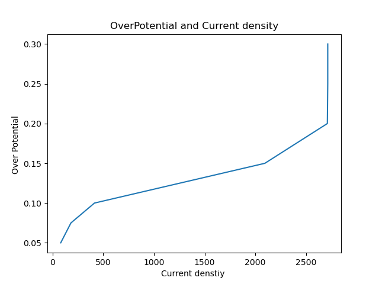

eta and I

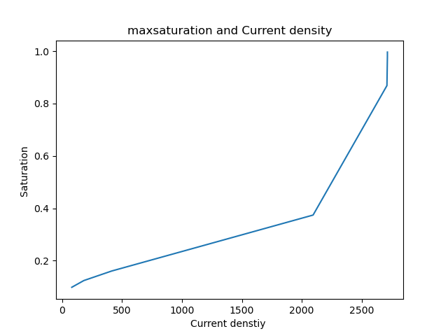

s max and I

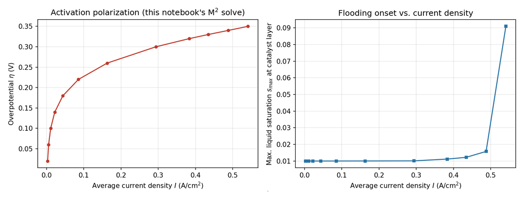

## Open Issue

- Oxygen concentration increases…….
- Log

At eta 0.05V theta=91: converged reason=-6, iterations=16 s range: [-0.0000, 0.0986] C range: [0.2110, 0.2142] 91 Average I ,79.90494487646504 91 voltage 1.1420095055123534…

At eta 0.075V theta=91: converged reason=-6, iterations=15 s range: [-0.0000, 0.1242] C range: [0.2122, 0.2193] 91 Average I ,180.48082396012325 91 voltage 1.1069519176039877…

At eta 0.1V theta=91: converged reason=-6, iterations=15 s range: [-0.0000, 0.1606] C range: [0.2149, 0.2311] 91 Average I ,412.7256010741574 91 voltage 1.058727439892584…

At eta 0.15V theta=91: converged reason=-6, iterations=16 s range: [-0.0000, 0.3743] C range: [0.2335, 0.3073] 91 Average I ,2094.1902091529264 91 voltage 0.8405809790847074…

At eta 0.2V theta=91: converged reason=-6, iterations=15 s range: [-0.0000, 0.8686] C range: [0.2433, 0.3376] 91 Average I ,2710.5697820194964 91 voltage 0.7289430217980504…

At eta 0.25V theta=91: converged reason=-6, iterations=9 s range: [-0.0000, 0.9804] C range: [0.2434, 0.3378] 91 Average I ,2714.5750849507135 91 voltage 0.6785424915049286…

At eta 0.3V theta=91: converged reason=-6, iterations=9 s range: [-0.0000, 0.9965] C range: [0.2434, 0.3378] 91 Average I ,2714.589699606669 91 voltage 0.628541030039333…

- visualization

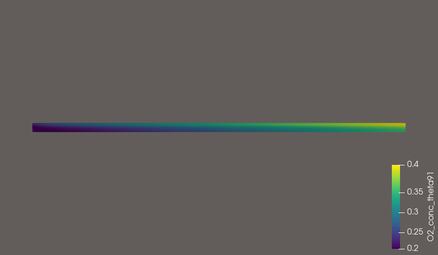

concent_oxygen